# How Russia’s Online Trolls Engaged Unsuspecting American Voters — And Sometimes Duped The Media

Data and [R](https://www.r-project.org/) code for the analysis supporting this [Oct. 25, 2018 BuzzFeed News post](https://www.buzzfeednews.com/article/peteraldhous/russia-online-trolls-viral-strategy) analyzing engagement with English-language tweets from the Kremlin-backed Internet Research Agency. Supporting files are in [this GitHub repository](https://github.com/BuzzFeedNews/2018-10-russian-troll-tweets).

### Data

On Oct. 16, 2018 Twitter [released a trove of data](https://about.twitter.com/en_us/values/elections-integrity.html#data) on accounts it had flagged as Russian trolls and shut down. Data on most of the 3.26 million English-language tweets from these accounts was [released in July](https://fivethirtyeight.com/features/why-were-sharing-3-million-russian-troll-tweets/) through FiveThirtyEight by researchers Darren Linvill and Patrick Warren of Clemson University in South Carolina. They also categorized the trolls into account categories including `LeftTroll`, and `RightTroll`. Many of the Left Trolls posed as liberal supporters of Black Lives Matter, tweeting about aspects of black culture as well as politics. Right Trolls posed as supporters of Donald Trump.

Download the Twitter data on Internet research agency tweets from [here](https://storage.googleapis.com/twitter-election-integrity/hashed/ira/ira_tweets_csv_hashed.zip), unzip, and place the file `ira_tweets_csv_hased.csv` in the `data` folder. Run the script `data_prep.R` to download the Clemson data, filter the Twitter data for English langauge tweets only, join the Clemson account categories to the Twitter data, and save as the file `en_ira_tweets.csv` in the `data` folder.

#### This file will contain the following fields:

##### From the Twitter data:

- `tweetid` Tweet identification number.
- `userid` User identification number (anonymized for users which had fewer than 5,000 followers at the time of suspension).
- `user_display_name` Name of the user (encoded as `userid` for anonymized users).
- `user_screen_name` Twitter handle of the user (encoded as `userid` for anonymized users).
- `user_reported_location` User’s self-reported location<sup>1</sup>.
- `user_profile_description` User’s profile description<sup>1</sup>.
- `user_profile_url` User’s profile URL<sup>1</sup>
- `follower_count` Number of accounts following the user<sup>1</sup>.
- `following_count` Number of accounts followed by the user<sup>1</sup>.
- `account_creation_date` Date of user account creation.
- `account_language` Language of the account as chosen by the user.
- `tweet_language` Language of the tweet.
- `tweet_text` Text of the tweet (mentions of anonymized accounts have been replaced with anonymized userid).
- `tweet_time` Time when the tweet was published (UTC).
- `tweet_client_name` Name of the client app used to publish the tweet.
- `in_reply_to_tweetid` The `tweetid` of the original tweet that this tweet is in reply to (for replies only).
- `in_reply_to_userid` The `userid` of the original tweet that this tweet is in reply to (for replies only).
- `quoted_tweet_tweetid` The `tweetid` of the original tweet that this tweet is quoting (for quotes only).
- `is_retweet` Is this tweet a retweet (“true” or “false”)?
- `retweet_userid` For retweets, `userid` that authored the original tweet.
- `retweet_tweetid` For retweets, `tweetid` of the original tweet.
- `latitude` Geolocated latitude, if available.
- `longitude` Geolocated longitude, if available.
- `quote_count` Number of tweets quoting this tweet.
- `reply_count` Number of tweets replying to this tweet.
- `like_count` Number of likes that this tweet received<sup>2</sup>.
- `retweet_count` Number of retweets that this tweet received<sup>2</sup>.
- `hashtags` a list of hashtags used in this tweet
- `urls` List of urls used in this tweet.
- `user_mentions` List of `userids` mentioned in this tweet (includes anonymized `userids`).
- `poll_choices` If a tweet included a poll, this field displays the poll choices separated by “|”.

##### From the Clemson data:

- `account_category` “LeftTroll”,“RightTroll”,“NewsFeed”,“HashtagGamer”,“NonEnglish”,“Fearmonger”,“Unknown”. See Linvill and Warren’s [research paper](http://pwarren.people.clemson.edu/Linvill_Warren_TrollFactory.pdf) for definitions.

##### Notes:

<sup>1</sup> At the time of account suspension.

<sup>2</sup> These engagement counts exclude engagements from users suspended, deleted, or otherwise sanctioned by Twitter at the time of the data release.

### Setting up

Load required packages and tweets data; extract date elements from timestamps.

```r
# load required packages
library(readr)
library(dplyr)
library(lubridate)
library(ggplot2)
library(scales)
library(DT)

# Set default timezone for session to UTC
Sys.setenv(TZ = "UTC")

# load data, extract date elements from timestamps
en_ira_tweets <- read_csv("data/en_ira_tweets.csv", col_types = cols(tweetid = col_character())) %>%
   mutate(tweet_date = as.Date(tweet_time),
          tweet_month = month(tweet_time),
          tweet_year = year(tweet_time))
```

### Tweets per month, by account category

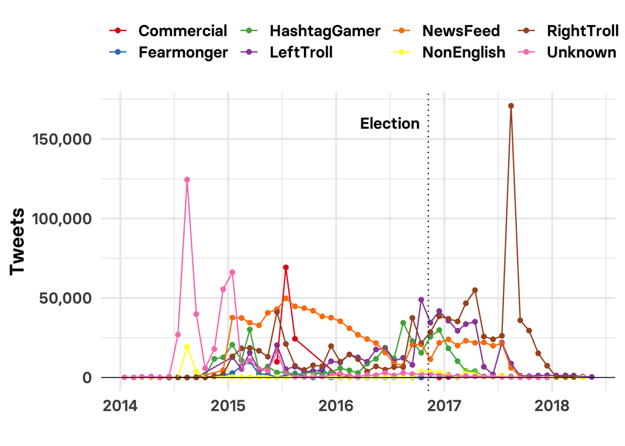

```r
tweets_category_month <- en_ira_tweets %>%
  group_by(tweet_year,tweet_month,account_category) %>%
  count() %>%
  filter(tweet_year >= 2014) %>% # there were very few tweets in earlier years
  mutate(date = as.Date(paste0(tweet_year,"-",tweet_month,"-15"))) # allows plotting in middle of month on date axis

ggplot(tweets_category_month, aes(x = date, y = n, color = account_category)) +
  geom_point() +
  geom_line() +
  xlab("") +
  ylab("Tweets") +
  geom_hline(yintercept = 0, size = 0.3) +
  geom_vline(xintercept = as.numeric(as.Date("2016-11-08")), linetype = "dotted") +
  annotate("text",
           x = as.Date("2016-07-01"),
           y = 160000,
           label = "Election",
           family = "BasierSquare-SemiBold",
           size = 4.5) +
  theme_minimal(base_size = 16, base_family = "BasierSquare-SemiBold") +
  scale_y_continuous(labels = comma) +
  scale_color_brewer(palette = "Set1", name = "") +
  theme(legend.position = "top")
```

### Tweet output and retweet counts by account category

#### Overall

```r
retweets_category <- en_ira_tweets %>%
  group_by(account_category) %>%
  summarize(tweets = n(),
            retweets = sum(retweet_count, na.rm = TRUE),
            mean_retweets = round(mean(retweet_count, na.rm=TRUE))) %>%
  arrange(-retweets) %>%
  mutate(percent = round(retweets/sum(retweets)*100,2),
         retweets = format(retweets, big.mark = ","),
         tweets = format(tweets, big.mark = ","))

datatable(retweets_category, colnames = c("Account category", "Tweets", "Retweet count", "Avg. per tweet", "% of total"))
```

|  | Account category | Tweets | Retweet count | Avg. per tweet | % of total |
| --- | --- | --- | --- | --- | --- |
| 1 | RightTroll | 892,549 | 11,160,542 | 13 | 50.93 |
| 2 | LeftTroll | 518,451 | 9,905,011 | 19 | 45.2 |
| 3 | NewsFeed | 891,482 | 652,371 | 1 | 2.98 |
| 4 | Unknown | 415,689 | 90,307 | 0 | 0.41 |
| 5 | HashtagGamer | 349,290 | 85,697 | 0 | 0.39 |
| 6 | NonEnglish | 52,844 | 15,290 | 0 | 0.07 |
| 7 | Commercial | 105,029 | 3,053 | 0 | 0.01 |
| 8 | Fearmonger | 36,597 | 995 | 0 | 0 |

#### In the year before the 2016 election

```r
pre_election <- en_ira_tweets %>%
  filter(tweet_date >= "2015-11-08" & tweet_date <= "2016-11-07")

retweets_category_pre <- pre_election %>%
  group_by(account_category) %>%
  summarize(tweets = n(),
            retweets = sum(retweet_count, na.rm = TRUE),
            mean_retweets = round(mean(retweet_count, na.rm=TRUE))) %>%
  arrange(-retweets) %>%
  mutate(percent = round(retweets/sum(retweets)*100,2),
         retweets = format(retweets, big.mark = ","),
         tweets = format(tweets, big.mark = ","))

datatable(retweets_category_pre, colnames = c("Account category", "Tweets", "Retweet count", "Avg. per tweet", "% of total"))
```

|  | Account category | Tweets | Retweet count | Avg. per tweet | % of total |
| --- | --- | --- | --- | --- | --- |
| 1 | RightTroll | 153,950 | 3,481,526 | 23 | 57.47 |
| 2 | LeftTroll | 183,901 | 2,206,818 | 12 | 36.43 |
| 3 | NewsFeed | 280,316 | 293,547 | 1 | 4.85 |
| 4 | HashtagGamer | 145,360 | 45,480 | 0 | 0.75 |
| 5 | Unknown | 20,712 | 27,743 | 1 | 0.46 |
| 6 | NonEnglish | 7,025 | 2,136 | 0 | 0.04 |
| 7 | Fearmonger | 5,777 | 659 | 0 | 0.01 |
| 8 | Commercial | 1,205 | 0 | 0 | 0 |

#### In the year after the 2016 election

```r
post_election <- en_ira_tweets %>%
  filter(tweet_date >= "2016-11-09" & tweet_date <= "2017-11-08")

retweets_category_post <- post_election %>%
  group_by(account_category) %>%
  summarize(tweets = n(),
            retweets = sum(retweet_count, na.rm = TRUE),
            mean_retweets = round(mean(retweet_count, na.rm=TRUE))) %>%
  arrange(-retweets) %>%
  mutate(percent = round(retweets/sum(retweets)*100,2),
         retweets = format(retweets, big.mark = ","),
         tweets = format(tweets, big.mark = ","))

datatable(retweets_category_post, colnames = c("Account category", "Tweets", "Retweet count", "Avg. per tweet", "% of total"))
```

|  | Account category | Tweets | Retweet count | Avg. per tweet | % of total |
| --- | --- | --- | --- | --- | --- |
| 1 | RightTroll | 549,109 | 7,468,392 | 14 | 57.78 |
| 2 | LeftTroll | 242,628 | 5,159,444 | 21 | 39.92 |
| 3 | NewsFeed | 191,121 | 255,417 | 1 | 1.98 |
| 4 | HashtagGamer | 89,991 | 25,850 | 0 | 0.2 |
| 5 | NonEnglish | 16,817 | 9,603 | 1 | 0.07 |
| 6 | Unknown | 9,291 | 6,164 | 1 | 0.05 |
| 7 | Commercial | 375 | 0 | 0 | 0 |
| 8 | Fearmonger | 2 | 0 | 0 | 0 |

### Tweet output and retweet counts by account

```r
retweets_account <- en_ira_tweets %>%
  group_by(userid,user_display_name,user_screen_name,account_category,user_profile_description) %>%
  summarize(followers = max(follower_count, na.rm = TRUE),
            tweets = n(),
            retweets = sum(retweet_count, na.rm = TRUE),
            mean_retweets = round(mean(retweet_count, na.rm = TRUE))) %>%
  arrange(-retweets)  %>%
  ungroup() %>%
  mutate(percent = round(retweets/sum(retweets)*100,2),
         followers = format(followers, big.mark = ","),
         tweets = format(tweets, big.mark = ","),
         retweets = format(retweets, big.mark = ",")) %>%
  select(-userid)

datatable(retweets_account, colnames = c("Display name", "Screen name", "Account category", "Profile description", "Followers", "Tweets", "Retweet count", "Avg. per tweet", "% of total"))
```

|  | Display name | Screen name | Account category | Profile description | Followers | Tweets | Retweet count | Avg. per tweet | % of total |
| --- | --- | --- | --- | --- | --- | --- | --- | --- | --- |
| 1 | Tennessee | TEN_GOP | RightTroll | Unofficial Twitter of Tennessee Republicans. Covering breaking news, national politics, foreign policy and more. #MAGA #2A | 147,767 | 10,500 | 5,986,737 | 571 | 27.32 |
| 2 | Crystal Johnson | Crystal1Johnson | LeftTroll | It is our responsibility to promote the positive things that happen in our communities. | 56,581 | 7,626 | 3,752,129 | 492 | 17.12 |
| 3 | Pamela Moore | Pamela_Moore13 | RightTroll | Southern. Conservative. Pro God. Anti Racism | 72,121 | 6,092 | 2,218,054 | 364 | 10.12 |
| 4 | Luisa Haynes | wokeluisa | LeftTroll | APSA. #Blackexcellence. Political science major | 57,295 | 2,274 | 1,216,444 | 535 | 5.55 |
| 5 | Jemisha | JemiSHaaaZzz | LeftTroll | Teacher, Reader, Writer, Resister. #Resistance RESPECT LOVE LOYALTY | 16,006 | 3,014 | 1,170,992 | 389 | 5.34 |
| 6 | Kanisha J | KaniJJackson | LeftTroll | Follow the example set by Mrs Obama; peace, love, acceptance &amp; vigilance #Impeach45 #Resist #GunReformNow | 34,276 | 3,638 | 820,178 | 226 | 3.74 |
| 7 | 1-800-WOKE-AF | gloed_up | LeftTroll | No black person is ugly #BRONZE #BlackLivesMatter #BlackToLive | 28,943 | 25,366 | 775,249 | 31 | 3.54 |
| 8 | Traynesha Cole 🌐 | TrayneshaCole | LeftTroll | Love for all my people of Melanin. Your BLACK is BEAUTIFUL! #MyPussyMyChoice #BlackGirlsMagic #BlackLivesMatter | 25,373 | 7,699 | 581,801 | 76 | 2.66 |
| 9 | Texas Lone Star | SouthLoneStar | RightTroll | Proud TEXAN and AMERICAN patriot #2a #prolife #Trump2016 #TrumpPence16 Fuck Islam and PC. Don't mess with Texas! | 53,999 | 3,519 | 555,483 | 158 | 2.53 |
| 10 | Jenna Abrams | Jenn_Abrams | RightTroll | Calm down, I'm not pro-Trump. I am pro-common sense. Any offers/ideas/questions? DM or email me jennnabrams@gmail.com (Yes, there are 3 Ns) | 79,152 | 23,163 | 543,197 | 23 | 2.48 |

[output cut: 3249 more lines]

### Top 1,000 tweets by retweet count

```r
top_tweets <- en_ira_tweets %>%
  arrange(-retweet_count) %>%
  head(1000) %>%
  select(user_display_name,user_screen_name,account_category,user_profile_description,tweet_text,tweet_date,retweet_count) %>%
  mutate(retweet_count = format(retweet_count, big.mark = ","))

datatable(top_tweets, colnames = c("Display name", "Screen name", "Account category", "Profile description", "Tweet text", "Date",  "Retweet count"))
```

|  | Display name | Screen name | Account category | Profile description | Tweet text | Date | Retweet count |
| --- | --- | --- | --- | --- | --- | --- | --- |
| 1 | Crystal Johnson | Crystal1Johnson | LeftTroll | It is our responsibility to promote the positive things that happen in our communities. | Daily reminder that the most educated First Lady in American history is a black woman with two Ivy League degrees from Harvard and Princeton https://t.co/oTBTmu2tCw | 2017-06-26 | 123,617 |
| 2 | Kanisha J | KaniJJackson | LeftTroll | Follow the example set by Mrs Obama; peace, love, acceptance &amp; vigilance #Impeach45 #Resist #GunReformNow | Obama (2012) sits alone in a classroom after meeting for hours with parents of Sandy Hook victims. Trump (2018) sits at a disco party he threw at his private night club after spending 14 minutes with … | 2018-02-18 | 113,066 |
| 3 | Crystal Johnson | Crystal1Johnson | LeftTroll | It is our responsibility to promote the positive things that happen in our communities. | These emotions... You can hear the pain in her voice😢 https://t.co/K98Fzep7K3 | 2016-09-27 | 97,498 |
| 4 | Jemisha | JemiSHaaaZzz | LeftTroll | Teacher, Reader, Writer, Resister. #Resistance RESPECT LOVE LOYALTY | Nigerian Physician, Dr. Oluyinka Olutoye cut a woman baby out her womb at 23 weeks old, successfully operated on the baby after taking out a tumor, then placed the baby back into the mum's womb &amp;a… | 2018-01-17 | 86,619 |
| 5 | Jemisha | JemiSHaaaZzz | LeftTroll | Teacher, Reader, Writer, Resister. #Resistance RESPECT LOVE LOYALTY | This adorable baby boy's smile is going to completely warm your heart. https://t.co/TWveXVtsJ7 | 2017-10-17 | 74,524 |
| 6 | Jemisha | JemiSHaaaZzz | LeftTroll | Teacher, Reader, Writer, Resister. #Resistance RESPECT LOVE LOYALTY | "This is what white people get to feel like ALL THE TIME?!" https://t.co/cMvvyNF8gN | 2017-12-23 | 65,564 |
| 7 | Jemisha | JemiSHaaaZzz | LeftTroll | Teacher, Reader, Writer, Resister. #Resistance RESPECT LOVE LOYALTY | Watch what happens when this big brother spots his little sister after getting off the school bus. It's priceless ❤ https://t.co/DKO2X3NMWa | 2017-11-16 | 59,292 |
| 8 | Luisa Haynes | wokeluisa | LeftTroll | APSA. #Blackexcellence. Political science major | Don’t ever tell me kneeling for the flag is disrespectful to our troops when Trump calls a sitting Senator “Pocahontas” in front of Native American war heroes. | 2017-11-27 | 51,472 |
| 9 | Crystal Johnson | Crystal1Johnson | LeftTroll | It is our responsibility to promote the positive things that happen in our communities. | If this little girl's way of reminding her dad to hold her hand isn't one of the cutest 10 seconds of video you've ever seen.. "Excuse me."😍 https://t.co/oCrbnCpI0u | 2017-08-06 | 51,285 |
| 10 | Crystal Johnson | Crystal1Johnson | LeftTroll | It is our responsibility to promote the positive things that happen in our communities. | This powerful video shows the conversations Black parents give to kids navigating racism https://t.co/cuCtPBSy7v | 2017-07-27 | 50,217 |

[output cut: 990 more lines]

### What were the retweet counts needed to get into the top 1 percent and 5 percent of tweets?

```r
quantile(en_ira_tweets$retweet_count, c(0.95, 0.99), na.rm = TRUE)
```

```
## 95% 99%
##   3  79
```

Five percent of tweets were retweeted 3 or more times; one percent of tweets were retweeted 79 times or more.

### Number of tweets for each account category in the top 1 percent for retweets

```r
top_pc_category <- en_ira_tweets %>%
  filter(retweet_count >= quantile(retweet_count, 0.99, na.rm = TRUE)) %>%
  group_by(account_category) %>%
  count() %>%
  arrange(-n) %>%
  mutate(n = format(n, big.mark = ","))

datatable(top_pc_category, colnames = c("Account category","Tweets in top 1%"))
```

|  | Account category | Tweets in top 1% |
| --- | --- | --- |
| 1 | RightTroll | 19,502 |
| 2 | LeftTroll | 12,869 |
| 3 | NewsFeed | 357 |
| 4 | Unknown | 42 |
| 5 | HashtagGamer | 38 |
| 6 | NonEnglish | 11 |
| 7 | Fearmonger | 1 |

### Top accounts, measured by number of tweets in the top 1 percent for retweets

```r
top_pc_accounts <- en_ira_tweets %>%
  filter(retweet_count >= quantile(retweet_count, 0.99, na.rm = TRUE)) %>%
  group_by(user_display_name, user_screen_name, account_category, user_profile_description, account_category) %>%
  count() %>%
  arrange(-n) %>%
  head(100) %>%
  mutate(n = format(n, big.mark = ","))

datatable(top_pc_accounts, colnames = c("Display name","Screen name","Account category","Profile description","Tweets in top 1%"))
```

|  | Display name | Screen name | Account category | Profile description | Tweets in top 1% |
| --- | --- | --- | --- | --- | --- |
| 1 | Tennessee | TEN_GOP | RightTroll | Unofficial Twitter of Tennessee Republicans. Covering breaking news, national politics, foreign policy and more. #MAGA #2A | 6,978 |
| 2 | Crystal Johnson | Crystal1Johnson | LeftTroll | It is our responsibility to promote the positive things that happen in our communities. | 4,543 |
| 3 | Pamela Moore | Pamela_Moore13 | RightTroll | Southern. Conservative. Pro God. Anti Racism | 4,453 |
| 4 | John Davis | TheFoundingSon | RightTroll | Business Owner, Proud Father, Conservative, Christian, Patriot, Gun rights, Politically Incorrect. Love my country and my family #2A #GOP #tcot #WakeUpAmerica | 1,586 |
| 5 | Jenna Abrams | Jenn_Abrams | RightTroll | Calm down, I'm not pro-Trump. I am pro-common sense. Any offers/ideas/questions? DM or email me jennnabrams@gmail.com (Yes, there are 3 Ns) | 1,450 |
| 6 | 1-800-WOKE-AF | gloed_up | LeftTroll | No black person is ugly #BRONZE #BlackLivesMatter #BlackToLive | 1,446 |
| 7 | Texas Lone Star | SouthLoneStar | RightTroll | Proud TEXAN and AMERICAN patriot #2a #prolife #Trump2016 #TrumpPence16 Fuck Islam and PC. Don't mess with Texas! | 1,411 |
| 8 | Black To Live | BlackToLive | LeftTroll | We want equality and justice! And we need you to help us. Join our team and write your own articles! DM us or send an email: BlackToLive@gmail.com | 1,291 |
| 9 | Luisa Haynes | wokeluisa | LeftTroll | APSA. #Blackexcellence. Political science major | 1,239 |
| 10 | Black News | BlackNewsOutlet | LeftTroll | Freedom is never given; it is won. #BlackLivesMatter | 986 |

[output cut: 90 more lines]

### How many tweets were retweets of other Russian troll tweets?

```r
en_ira_tweets %>%
  filter(retweet_userid %in% unique(userid)) %>%
  tally()
```

```
## # A tibble: 1 x 1
##        n
##    <int>
## 1 137653
```

Just 137,653 of the 3.26 million tweets were retweets of other known Russian trolls.

### The birth and death of @TEN_GOP and related accounts

```r
ten_gop_related <- en_ira_tweets %>%
  filter(grepl("_gop", user_screen_name, ignore.case = TRUE)) %>%
  group_by(user_display_name,user_screen_name,user_profile_description,account_creation_date) %>%
  summarize(last_tweeted = max(tweet_date))

datatable(ten_gop_related, colnames = c("Display name","Screen name","Profile description","Account created","Last tweeted"))
```

|  | Display name | Screen name | Profile description | Account created | Last tweeted |
| --- | --- | --- | --- | --- | --- |
| 1 | 10 GOP | 10_gop | Conservative, daily news that you won't find on mainstream media. #MAGA Retweeted by @realDonaldTrump 😇 | 2017-09-07 | 2017-10-15 |
| 2 | ELEVEN GOP | ELEVEN_GOP | This is our back-up account in case anything happens to @TEN_GOP | 2015-11-18 | 2017-07-27 |
| 3 | Tennessee | realTEN_GOP | This is our backup account in case anything happens to @TEN_GOP | 2017-08-24 | 2017-08-28 |
| 4 | Tennessee | TEN_GOP | Unofficial Twitter of Tennessee Republicans. Covering breaking news, national politics, foreign policy and more. #MAGA #2A | 2015-11-19 | 2017-08-24 |